# Introduction to homework

Wang Peiyi

2024-12-06

# A-SC24002027-2024-09-09

## Question

Use knitr to produce at least 3 examples. For each example, texts should mix with figures and/or tables. Better to have mathematical formulas.

## Answer

### Example 1

使用R语言进行线性回归分析的一个例子。

Choosing to execute and show R code.

```r
ctl <- c(4.17,5.58,5.18,6.11,4.50,4.61,5.17,4.53,5.33,5.14)
trt <- c(4.81,4.17,4.41,3.59,5.87,3.83,6.03,4.89,4.32,4.69)
group <- gl(2, 10, 20, labels = c("Ctl","Trt")) #创建了一个包含20个元素的因子，其中前10个元素标记为"Ctl"，后10个元素标记为"Trt"
weight <- c(ctl, trt)
lm.D9 <- lm(weight ~ group)#进行线性回归分析
summary(lm.D9)$coef
```

```
##             Estimate Std. Error  t value     Pr(>|t|)
## (Intercept)    5.032  0.2202177 22.85012 9.547128e-15
## groupTrt      -0.371  0.3114349 -1.19126 2.490232e-01
```

The $R^2$ is 0.0730776.

Choosing to execute but not show R code.

```
##             Estimate Std. Error  t value     Pr(>|t|)
## (Intercept)    5.032  0.2202177 22.85012 9.547128e-15
## groupTrt      -0.371  0.3114349 -1.19126 2.490232e-01
```

Choosing to show but not execute R code.

```r
ctl <- c(4.17,5.58,5.18,6.11,4.50,4.61,5.17,4.53,5.33,5.14)
trt <- c(4.81,4.17,4.41,3.59,5.87,3.83,6.03,4.89,4.32,4.69)
group <- gl(2, 10, 20, labels = c("Ctl","Trt"))
weight <- c(ctl, trt)
lm.D9 <- lm(weight ~ group)
summary(lm.D9)$coef
```

### Example 2

获取iris数据集的前六行数据转换为一个LaTeX格式的表格，将所得结果放进latex后得到表格。

```r
library(xtable)
xtable::xtable(head(iris))
```

```
## % latex table generated in R 4.4.2 by xtable 1.8-4 package
## % Sat Dec  7 10:38:25 2024
## \begin{table}[ht]
## \centering
## \begin{tabular}{rrrrrl}
##   \hline
##  & Sepal.Length & Sepal.Width & Petal.Length & Petal.Width & Species \\
##   \hline
## 1 & 5.10 & 3.50 & 1.40 & 0.20 & setosa \\
##   2 & 4.90 & 3.00 & 1.40 & 0.20 & setosa \\
##   3 & 4.70 & 3.20 & 1.30 & 0.20 & setosa \\
##   4 & 4.60 & 3.10 & 1.50 & 0.20 & setosa \\
##   5 & 5.00 & 3.60 & 1.40 & 0.20 & setosa \\
##   6 & 5.40 & 3.90 & 1.70 & 0.40 & setosa \\
##    \hline
## \end{tabular}
## \end{table}
```

### Example 3

绘制example 1的线性模型的图。

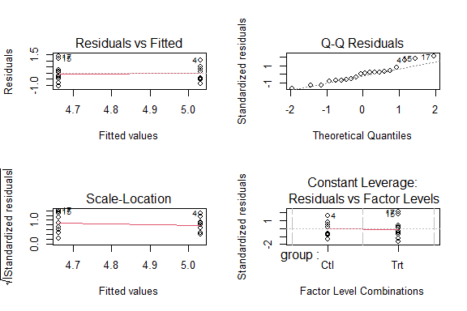

```r
par(mfrow=c(2,2))#图形参数设置
plot(lm.D9)
```

### Mathematical formulas

$$\begin{align*}
\bigtriangledown \times H=J+\frac{\partial D}{\partial t} \\
\bigtriangledown \times E=-\frac{\partial B}{\partial t} \\
\bigtriangledown \cdot B=0 \\
\bigtriangledown \cdot D=\rho
\end{align*}$$

# A-SC24002027-2024-09-14

## Question 1

3.4

The Rayleigh density is
$$f(x) = \frac { x } { \sigma ^ {2} }e ^ {- x ^ {2} / ( 2 \sigma ^ {2} )}
, \quad x \ge 0\quad \sigma > 0$$
Develop an algorithm to generate random samples from a Rayleigh ( $\sigma$ ) distribution. Generate Rayleigh ( $\sigma$ ) samples for several choices of $\sigma$ > 0 and check that the mode of the generated samples is close to the theoretical mode $\sigma$ (check the histogram).

## Answer

考虑到瑞利分布分布函数(CDF)的逆函数容易得到，使用逆变换法来获得瑞利分布的随机数。
$$\int f(x) dx = \int \frac { x } { \sigma ^ {2} }e ^ {- x ^ {2} / ( 2
\sigma ^ {2} )} dx\\
= - e ^ { - x ^ { 2 } / 2 \sigma ^ { 2 } } + C$$
则瑞利分布的分布函数(CDF)为:
$$F(x) = 1 - e ^ { - x ^ { 2 } / 2 \sigma ^ { 2 } }$$
其逆函数为:
$$X = \sigma \sqrt{-2ln(1-u)}$$
接下来使用代码生成瑞利分布随机数:

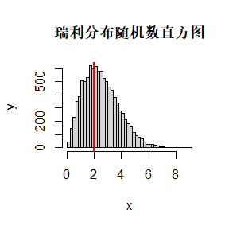

```r
# 设置参数
sigma <- 2
n=10000

# 生成瑞利分布样本
set.seed(24002027)
u <- runif(n) # 生成均匀分布的随机数
x <- sigma * sqrt(-2 * log(1 - u)) # 逆函数

# 画出直方图和理论sigma线
hist(x, breaks = 50, ylab = "y", xlab = "x", main = "瑞利分布随机数直方图")
abline(v = sigma, col = "red", lwd = 3)
```

可以看出理论值接近估计值。

## Question 2

3.11

Generate a random sample of size 1000 from a normal location mixture. The components of the mixture have N (0, 1) and N (3, 1) distributions with mixing probabilities p1 and $p_2$ = 1 − $p_1$. Graph the histogram of the sample with density superimposed, for $p_1$ = 0.75. Repeat with different values for p1 and observe whether the empirical distribution of the mixture appears to be bimodal. Make a conjecture about the values of p1 that produce bimodal mixtures.

## Answer

对于生成混合正态分布，考虑使用rbinom函数来生随机成概率概率为$p_1$的二项分布来判别样本来自哪个正态分布，再使用rnorm函数生成正态分布并绘制直方图和密度函数。

接下来使用r语言绘制$p_1=0.75$时的直方图和密度曲线。

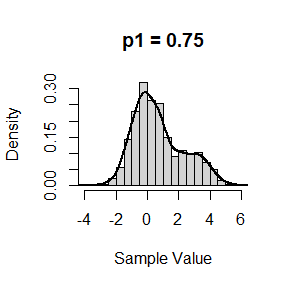

```r
# 设置参数
n <- 1000
p1 <- 0.75

# 生成混合正态分布样本
set.seed(24002027)
x <- rbinom(n, 1, p1) # 生成概率为0.75的二项分布来决定样本是来自哪个正态分布的
sample <- x * rnorm(n, 0, 1) + (1 - x) * rnorm(n, 3, 1) # 利用二项分布生成混合正态分布

# 绘制直方图和密度曲线
hist(sample, breaks = 30, probability = TRUE,  main = paste("p1 =", p1), xlab = "Sample Value", ylab = "Density")
lines(density(sample), col = "black", lwd = 2)
```

接下来测试不同概率下的直方图和密度曲线

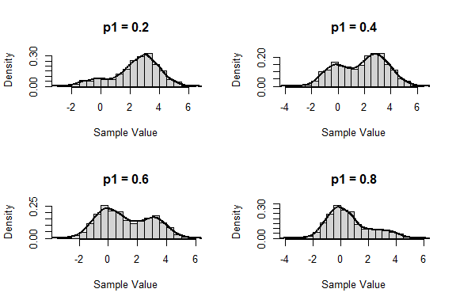

```r
# 测试不同概率下的直方图和密度曲线
n <- 1000
p <- seq(0.2, 0.8, by = 0.2)

par(mfrow = c(2, 2))

for (p1 in p){

# 生成混合正态分布样本
set.seed(24002027)
x <- rbinom(n, 1, p1) # 生成概率为0.75的二项分布来决定样本是来自哪个正态分布的
sample <- x * rnorm(n, 0, 1) + (1 - x) * rnorm(n, 3, 1) # 利用二项分布生成混合正态分布

# 绘制直方图和密度曲线
hist(sample, breaks = 30, probability = TRUE,  main = paste("p1 =", p1), xlab = "Sample Value", ylab = "Density")
lines(density(sample), col = "black", lwd = 2)

}
```

## Question 3

3.20

A compound Poisson process is a stochastic process {$X(t), t \geq 0$} that can be represented as the random sum $X(t) = \sum_{i=1}^{N(t)} Y_i, \quad t \geq 0$ where {$X(t), t \geq 0$} is a Poisson process and $Y_1$, $Y_2$, . . . are iid and independent of {$X(t), t \geq 0$}. Write a program to simulate a compound Poisson(λ)–Gamma process (Y has a Gamma distribution). Estimate the mean and the variance of X(10) for several choices of the parameters and compare with the theoretical values. Hint: Show that $E[X(t)] = λtE[Y_1]$ and $Var(X(t)) = λtE[Y_1^2]$.

## Answer

首先我们来给出泊松—伽马过程的理论均值和方差的表达式。 定义$X(t) = \sum_{i=1}^{N(t)} Y_i, \quad t \geq 0$为泊松—伽马过程，由于 $Y_i$ 是独立同分布的且与 $N(t)$ 独立,我们得到：
$$E[X(t)] = E\left[\sum_{i=1}^{N(t)} Y_i\right]\\
=E[N(t)] \cdot E[Y_1]\\
=\lambda t \cdot E[Y_1]$$
$$Var(X(t)) = Var\left(\sum_{i=1}^{N(t)} Y_i\right)\\
= E[N(t)] \cdot Var(Y_1) + Var(N(t)) \cdot (E[Y_1])^2\\
= \lambda t \cdot Var(Y_1) + \lambda t \cdot (E[Y_1])^2$$
再由$Var(Y_1) = E[Y_1^2] - (E[Y_1])^2$得到:
$$Var(X(t)) = \lambda t \cdot (E[Y_1^2] - (E[Y_1])^2) + \lambda t \cdot
(E[Y_1])^2\\
=\lambda t \cdot E[Y_1^2]$$
综上所述，
$$E[X(t)] = \lambda t \cdot E[Y_1]\\
Var(X(t)) = \lambda t \cdot E[Y_1^2]$$
接下来计算$E(Y_1^2)$: 我们知到
$$Var(Y_1) = \frac{\alpha}{\beta^2}$$
而
$$E(Y_1) = \frac{\alpha}{\beta}$$
再由方差和期望的公式得到
$$\frac{\alpha}{\beta^2} = E(Y_1^2) - \left(\frac{\alpha}{\beta}\right)^2$$
解得:
$$E(Y_1^2)=\frac{\alpha (\alpha + 1)}{\beta^2}$$

可知理论结果可以由伽马分布的均值和二阶矩得到。

接下来我们使用r语言模拟泊松—伽马过程。

步骤大致为: 用for循环设置3组不同的参数，再用function定义模拟复合泊松—伽马过程，再经过模拟求得不同参数下的结果。

```r
set.seed(24002027)  # 设置随机数种子

lambda_p <- c(3,5,7)
alpha_p <- c(2,4,6)
beta_p <- c(1,3,5) # 设置三组参数

# 分别计算三组参数下的结果
for (i in 1:3) {
# 定义参数
lambda <- lambda_p[i]  # 泊松过程的参数
alpha <- alpha_p[i]   # 伽马分布的形状参数
beta <- beta_p[i]   # 伽马分布的尺度参数
t <- 10      # 时间
n <- 10000  # 模拟次数

# 模拟复合泊松-伽马过程
poisson_gamma <- function(lambda, alpha, beta, t, n_sim) {
  X_t <- numeric(n)  # 初始化X(t)的存储向量
  for (i in 1:n) {
    N_t <- rpois(1, lambda * t)  # 模拟泊松过程N(t)
    Y_i <- rgamma(N_t, alpha, beta)  # 模拟伽马分布随机变量
    X_t[i] <- sum(Y_i)  # 计算X(t)
  }
  return(X_t)
}

# 模拟过程并计算均值和方差
X_10 <- poisson_gamma(lambda, alpha, beta, t, n)
s_mean <- mean(X_10)
s_var <- var(X_10)

# 计算理论均值和方差
E_Y1 <- alpha / beta  # 伽马分布的均值
E_Y1_2 <- (alpha*(alpha+1)) / beta^2 # 伽马分布随机变量Y_1的二阶矩
t_mean <- lambda * t * E_Y1
t_var <- lambda * t * E_Y1_2

# 输出结果
cat("参数设置为lambda=",lambda_p[i],"alpha=", alpha_p[i], "beta=", beta_p[i], "的结果", "\n")
cat("模拟得到的X(10)的均值:", s_mean, "\n")
cat("模拟得到的X(10)的方差:", s_var, "\n")
cat("理论得到的X(10)的均值:", t_mean, "\n")
cat("理论得到的X(10)的方差:", t_var, "\n")
}
```

```
## 参数设置为lambda= 3 alpha= 2 beta= 1 的结果
## 模拟得到的X(10)的均值: 59.95586
## 模拟得到的X(10)的方差: 181.183
## 理论得到的X(10)的均值: 60
## 理论得到的X(10)的方差: 180
## 参数设置为lambda= 5 alpha= 4 beta= 3 的结果
## 模拟得到的X(10)的均值: 66.76788
## 模拟得到的X(10)的方差: 112.2937
## 理论得到的X(10)的均值: 66.66667
## 理论得到的X(10)的方差: 111.1111
## 参数设置为lambda= 7 alpha= 6 beta= 5 的结果
## 模拟得到的X(10)的均值: 84.10536
## 模拟得到的X(10)的方差: 118.2692
## 理论得到的X(10)的均值: 84
## 理论得到的X(10)的方差: 117.6
```

易知，模拟结果接近理论计算值。

# A-SC24002027-2024-09-23

## Question 1

For n = $10^4$, 2 × $10^4$, 4 × $10^4$, 6 × $10^4$, 8 × $10^4$, apply the fast sorting algorithm to randomly permuted numbers of 1, … , n. 2. Calculate computation time averaged over 100 simulations, denoted by an. 3. Regress an on $t_n$ := nlog(n), and graphically show the results (scatter plot and regression line).

## Answer

先定义快速排序函数，再分别将n的值带入函数计算100次并得到平均时间，最后将时间进行线性回归。

```r
rm(list=ls()) #清理内存
set.seed(24002027)

# 定义快速排序函数
quick_sort <- function(x) {
  num <- length(x)
  if (num == 0 || num == 1) {
    return(x)
  } else {
    a <- x[1]
    y <- x[-1]
    lower <- y[y < a]
    upper <- y[y >= a]
    return(c(quick_sort(lower), a, quick_sort(upper)))
  }
}

# 生成数据
# 定义n的取值
n_values <- c(1e4, 2e4, 4e4, 6e4, 8e4)

# 初始化存储计算时间的向量
a_n <- numeric(length(n_values))

# 统计推理
# 进行100次模拟并计算平均时间
for (i in seq_along(n_values)) {
  n <- n_values[i]
  times <- numeric(100)
  for (j in 1:100) {
    test <- sample(1:n)
    times[j] <- system.time(quick_sort(test))[1]
  }
  a_n[i] <- mean(times)
}

cat("平均时间分别为",a_n)
```

```
## 平均时间分别为 0.016 0.0322 0.0713 0.1113 0.141
```

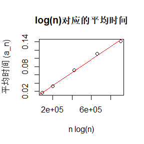

```r
# 计算tn = n * log(n)
t_n <- n_values * log(n_values)

# 线性回归
model <- lm(a_n ~ t_n)

# 输出结果
# 绘图
plot(t_n, a_n, main = "log(n)对应的平均时间", xlab = "n log(n)", ylab = "平均时间 (a_n)", pch = 1)
abline(model, col = "red")
```

## Question 2

5.4

Write a function to compute a Monte Carlo estimate of the Beta(3, 3) cdf, and use the function to estimate F (x) for x = 0.1, 0.2,…, 0.9. Compare the estimates with the values returned by the pbeta function in R.

## Answer

先用用function定义一个函数使用蒙特卡洛法估计Beta(3,3)的累积分布函数，再定义x的值并使用这些值计算对应的蒙特卡洛法估计的值和函数pbeta对应的值。

```r
rm(list=ls()) #清理内存
set.seed(24002027)

#生成数据
# 定义蒙特卡洛法估计Beta(3, 3)的累积分布函数函数
mc_beta_cdf <- function(x, n_sim = 10000) {
  samples <- rbeta(n_sim, 3, 3) # 生成Beta(3, 3)分布
  cdf_estimates <- sapply(x, function(q) mean(samples <= q)) # 生成Beta(3, 3)分布的累积分布函数
  return(cdf_estimates)
}

# 定义x的取值
x_values <- seq(0.1, 0.9, by = 0.1)

# 统计推理
# 计算蒙特卡洛估计的CDF值
mc_estimates <- mc_beta_cdf(x_values)

# 使用pbeta函数计算真实的CDF值
pbeta_values <- pbeta(x_values, 3, 3)

# 输出结果
results <- data.frame(x = x_values, MonteCarlo = mc_estimates, Pbeta = pbeta_values)
print(results)
```

```
##     x MonteCarlo   Pbeta
## 1 0.1     0.0070 0.00856
## 2 0.2     0.0556 0.05792
## 3 0.3     0.1669 0.16308
## 4 0.4     0.3217 0.31744
## 5 0.5     0.5037 0.50000
## 6 0.6     0.6883 0.68256
## 7 0.7     0.8385 0.83692
## 8 0.8     0.9424 0.94208
## 9 0.9     0.9920 0.99144
```

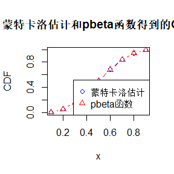

```r
# 绘制比较图
plot(x_values, mc_estimates, type = "b", col = "blue", pch = 1,
     xlab = "x", ylab = "CDF", main = "蒙特卡洛估计和pbeta函数得到的CDF")
lines(x_values, pbeta_values, type = "b", col = "red", pch = 2)
legend("bottomright", legend = c("蒙特卡洛估计", "pbeta函数"),
       col = c("blue", "red"), pch = c(1, 2))
```

## Question 3

5.9

The Rayleigh density is
$$f(x) = \frac { x } { \sigma ^ {2} }e ^ {- x ^ {2} / ( 2 \sigma ^ {2} )}
, \quad x \ge 0\quad \sigma > 0$$
Implement a function to generate samples from a Rayleigh(σ) distribution, using antithetic variables. What is the percent reduction in variance of $\frac {X+X'}{2}$compared with $\frac {X_1+X_2}{2}$ for independent $X_1$, $X_2$ ?

## Answer

先用均匀分布分别定义生成简单估计量瑞利分布样本的函数和对偶估变量的瑞利分布样本函数，再分别计算$\frac {X_1+X_2}{2}$和$\frac {X+X'}{2}$的样本均值和方差。

```r
rm(list=ls()) #清理内存
set.seed(24002027) # 种子

# 生成数据
# 瑞利分布
generate_rayleigh <- function(sigma, n, antithetic = FALSE) {
  u <- runif(n / 2) # 生成 n/2 个均匀随机数 u
  if (antithetic) { #生成对偶变量
    v <- 1 - u
  } else {
    v <- runif(n / 2) # 正常生成瑞利分布
  }
  u <- c(u, v)
  rayleigh_samples <- sigma * sqrt(-2 * log(u))
  return(rayleigh_samples)
}
sigma <- 1
n <- 10000
m <- 1000

# 统计推理
# 使用对偶变量生成样本
samples_antithetic <- replicate(m, mean(generate_rayleigh(sigma, n, antithetic = TRUE)))
# 使用独立变量生成样本
samples_independent <- replicate(m, mean(generate_rayleigh(sigma, n, antithetic = FALSE)))

# 计算方差
var_antithetic <- var(samples_antithetic)
var_independent <- var(samples_independent)

# 计算方差减少百分比
percent_reduction <- (var_independent - var_antithetic) / var_independent * 100

#输出结果
cat("方差减少百分比为：", percent_reduction, "%\n")
```

```
## 方差减少百分比为： 94.95674 %
```

## Quwstion 4

5.13

Find two importance functions f1 and f2 that are supported on (1, $\infty$) and are ‘close’ to
$$g(x)=\frac { x ^ 2 } { \sqrt {2\pi} }e ^ {- x ^ {2} / 2 } dx$$
Which of your two importance functions should produce the smaller variance in estimating
$$\int_{1}^{\infty} \frac { x ^ 2 } { \sqrt {2\pi} }e ^ {- x ^ {2} / 2 }
dx$$
by importance sampling? Explain.

## Answer

对于给定的函数g(x)，根据重要抽样的原理
$$\theta =\int g(x) dx=\int \frac {g(x)} {f(x)} f(x)dx=E( \frac {g(x)}
{f(x)})=\frac {1} {m} \sum_{i=1}^{m}\frac {g(X_i)} {f(X_i)}$$
考虑到正态分布N(1,1)的概率密度函数与g(x)较为接近，以及指数分布e(1)的长尾特性，我们选择这两个分布的密度函数作为f(x),分别计算它们的权重后求期望得到结果。

```r
rm(list=ls()) #清理内存
set.seed(24002027)

# 生成数据
# 定义给定的函数 g(x)
g <- function(x) {
  (x^2 / sqrt(2 * pi)) * exp(-x^2 / 2)
}

# 定义两个重要性函数 f1 和 f2
f1 <- function(x) {
  dnorm(x, mean = 1, sd = 1)  # 正态分布，均值为2，标准差为1
}

f2 <- function(x) {
  dexp(x - 1, rate = 1)  # 指数分布，移位参数为1
}

# 统计推理
# 计算积分的真实值
true_value <- integrate(g, lower = 1, upper = Inf)$value

# 重要性抽样函数
importance_sampling <- function(f, n = 10000) {
  samples <- rexp(n, rate = 1) + 1  # 生成样本
  weights <- g(samples) / f(samples)  # 计算权重
  estimate <- mean(weights)  # 估计值
  variance <- var(weights) / n  # 方差
  list(estimate = estimate, variance = variance)
}

# 计算 f1 和 f2 的估计值和方差
result_f1 <- importance_sampling(f1)
result_f2 <- importance_sampling(f2)

# 输出结果
cat("f1 的估计值:", result_f1$estimate, "方差:", result_f1$variance, "\n")
```

```
## f1 的估计值: 0.7587088 方差: 1.951821e-06
```

```r
cat("f2 的估计值:", result_f2$estimate, "方差:", result_f2$variance, "\n")
```

```
## f2 的估计值: 0.4005125 方差: 2.455116e-06
```

可以看到，使用正态分布N(1,1)得到的方差更小。 下面解释原因。 首先我们画出g(x)和N(1,1)、e(1)的概率密度图像。

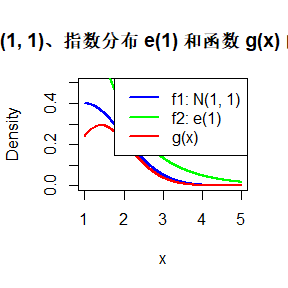

```r
rm(list=ls()) #清理内存
set.seed(24002027)
# 定义正态分布 N(1, 1) 的概率密度函数
f1 <- function(x) {
  1 / sqrt(2 * pi) * exp(-0.5 * (x - 1)^2)
}

# 定义指数分布 e(1) 的概率密度函数
f2 <- function(x) {
  ifelse(x >= 1, exp(-(x - 1)), 0)
}

# 定义函数 g(x)
g <- function(x) {
  (x^2 / sqrt(2 * pi)) * exp(-x^2 / 2)
}

# 创建数据用于绘图
x_values <- seq(1, 5, length.out = 1000)
f1_values <- f1(x_values)
f2_values <- f2(x_values)
g_values <- g(x_values)

# 绘制对比图
plot(x_values, f1_values, type = "l", col = "blue", lwd = 2, ylim = c(0, 0.5),
     ylab = "Density", xlab = "x", main = "正态分布 N(1, 1)、指数分布 e(1) 和函数 g(x) 的对比图 (x ≥ 1)")
lines(x_values, f2_values, col = "green", lwd = 2)
lines(x_values, g_values, col = "red", lwd = 2)
legend("topright", legend = c("f1: N(1, 1)", "f2: e(1)", "g(x)"), col = c("blue", "green", "red"), lwd = 2)
```

我们发现正态分布N(1,1)的图像最接近g(x)，可以认为正态分布密度函数组的权重波动较小更均匀，所以方差更小。

# A-SC24002027-2024-09-30

## Question 1

If we obtain the powers for two methods under a particular simulation setting with 10,000 experiments: say, 0.651 for one method and 0.676 for another method. We want to know if the powers are different at 0.05 level.

1. What is the corresponding hypothesis test problem?
2. What test should we use? Z-test, two-sample t-test, paired-t test or McNemar test? Why?
3. Please provide the least necessary information for hypothesis testing.

## Answer

1. 原假设($H_0$): 两种方法的统计功效相等。($P_1=P_2$) 备选假设($H_1$): 两种方法统计功效不同。($P_1\neq P_2$)
2. 适用的检验: 两样本比例的z检验。 原因: 样本量较大，且对比量为比例。两样本t检验和配对t检验适合比较均值，McNemar检验通常在前后研究设计中使用，不适合这里。
3. 必要的信息: (1)两个样本的统计功效值。(2)样本大小。(3)显著性水平。

## Question 2

6.6

Estimate the 0.025, 0.05, 0.95, and 0.975 quantiles of the skewness $\sqrt {b_1}$ under normality by a Monte Carlo experiment. Compute the standard error of the estimates from (2.14) using the normal approximation for the density (with exact variance formula). Compare the estimated quantiles with the quantiles of the large sample approximation $\sqrt {b_1}$ ≈ N (0, 6/n).

其中(2.14)为:
$$\mathrm{Var}(\hat{x}_{q}) = \frac{q(1 - q)}{nf(x_{q})^{2}}$$
where f is the density of the sampled distribution.

思路：生成偏度的蒙特卡洛样本计算偏度，再使用quantile函数根据偏度计算分位数，再通过公式（2.14）以及标准误差公式$se=\frac {sd}{\sqrt {n}}$计算分位数的标准误差。

```r
rm(list=ls()) #清理内存
set.seed(24002027)

# 数据生成
# 参数设置
n <- 1000  # 样本大小
num_simulations <- 100000  # 模拟次数

# 生成偏度的Monte Carlo样本
skewness_samples <- numeric(num_simulations)
for (i in 1:num_simulations) {
  sample <- rnorm(n)
  skewness_samples[i] <- mean((sample - mean(sample))^3) / sd(sample)^3 # 计算偏度
}

# 统计推理
# 计算分位数
quantiles <- quantile(skewness_samples, probs = c(0.025, 0.05, 0.95, 0.975))

# 计算标准误差
q_values <- c(0.025, 0.05, 0.95, 0.975)
standard_errors <- numeric(length(q_values))
for (i in 1:length(q_values)) {
  f_q <- dnorm(qnorm(q_values[i]))
  standard_errors[i] <- sqrt(q_values[i] * (1 - q_values[i]) / (n * f_q^2))/sqrt(n) # 计算偏度标准误差
}

# 大数近似下的分位数
large_sample_quantiles <- qnorm(q_values, mean = 0, sd = sqrt(6/n))

# 输出结果
cat("Monte Carlo估计的分位数:\n",quantiles,"\n","标准误差:","\n",standard_errors,"\n","大样本近似的分位数:","\n",large_sample_quantiles)
```

```
## Monte Carlo估计的分位数:
##  -0.1503208 -0.1263732 0.1269625 0.1510232
##  标准误差:
##  0.002671311 0.002113188 0.002113188 0.002671311
##  大样本近似的分位数:
##  -0.1518182 -0.1274098 0.1274098 0.1518182
```

对比可知，根据蒙特卡洛实验估计出的正态分布下偏度的分位数与根据大样本近似方法得到的分位数基本一致。

## Question 3

6.B

Tests for association based on Pearson product moment correlation $\rho$, Spearman’s rank correlation coefficient $\rho_s$, or Kendall’s coefficient $\tau$, are implemented in cor.test. Show (empirically) that the nonparametric tests based on $\rho_s$ or $\tau$ are less powerful than the correlation test when the sampled distribution is bivariate normal. Find an example of an alternative (a bivariate distribution (X, Y ) such that X and Y are dependent) such that at least one of the nonparametric tests have better empirical power than the correlation test against this alternative.

## Answer

思路: 生成数据后，使用三个变量来储存拒绝的次数，通过cor.test计算出三个检验方法的相关系数，通过if函数来判定模拟实验中的拒绝次数并记录在变量中，再通过总样本数计算出拒绝率，借此判断三者的功效。

首先先模拟实验对比双变量正态分布下的功效。

借助MASS库生成双变量正态分布。

```r
rm(list=ls()) #清理内存
set.seed(24002027)

# 数据生成
# 设置参数
library(MASS)
n <- 100
mu <- c(0, 0)
Sigma <- matrix(c(1, 0.5, 0.5, 1), 2, 2)
num_simulations <- 10000
alpha <- 0.05

# 存储拒绝次数
pearson_rejections <- 0
spearman_rejections <- 0
kendall_rejections <- 0

# 统计推理
# 进行模拟实验
for (i in 1:num_simulations) {
  data_normal <- mvrnorm(n, mu, Sigma)

  pearson_test <- cor.test(data_normal[,1], data_normal[,2], method = "pearson")
  spearman_test <- cor.test(data_normal[,1], data_normal[,2], method = "spearman")
  kendall_test <- cor.test(data_normal[,1], data_normal[,2], method = "kendall") # 计算相关系数

  if (pearson_test$p.value < alpha) pearson_rejections <- pearson_rejections + 1
  if (spearman_test$p.value < alpha) spearman_rejections <- spearman_rejections + 1
  if (kendall_test$p.value < alpha) kendall_rejections <- kendall_rejections + 1 # 如果p值小于alpha，计入拒绝次数
}

# 计算拒绝率
pearson_power <- pearson_rejections / num_simulations
spearman_power <- spearman_rejections / num_simulations
kendall_power <- kendall_rejections / num_simulations

# 输出结果
cat("双变量正态分布Pearson测试功效: ", pearson_power, "\n","双变量正态分布Spearman测试功效: ", spearman_power, "\n","双变量正态分布Kendall测试功效: ", kendall_power, "\n")
```

```
## 双变量正态分布Pearson测试功效:  0.9997
##  双变量正态分布Spearman测试功效:  0.9994
##  双变量正态分布Kendall测试功效:  0.9994
```

可以看出Pearson测试的功效高于Spearman和Kendall测试。 接下来我们生成相关的双变量分布来对比测试的功效。选择的分布为:X服从正态分布，Y是混合分布是X的线性变换与另一个服从对数正态分布的随机变量的和。

```r
# 存储结果
pearson_rejections2 <- 0
spearman_rejections2 <- 0
kendall_rejections2 <- 0

# 统计推理
# 进行模拟实验
for (i in 1:num_simulations) {
  X <- rnorm(n)
  Y <- 2 * X + rlnorm(n)  # 生成相关的双变量分布数据

  pearson_test2 <- cor.test(X, Y, method = "pearson")
  spearman_test2 <- cor.test(X, Y, method = "spearman")
  kendall_test2 <- cor.test(X, Y, method = "kendall") # 计算相关系数

  if (pearson_test2$p.value < alpha) pearson_rejections2 <- pearson_rejections2 + 1
  if (spearman_test2$p.value < alpha) spearman_rejections2 <- spearman_rejections2 + 1
  if (kendall_test2$p.value < alpha) kendall_rejections2 <- kendall_rejections2 + 1 # # 如果p值小于alpha，计入拒绝次数
}

# 计算拒绝率
pearson_power2 <- pearson_rejections2 / num_simulations
spearman_power2 <- spearman_rejections2 / num_simulations
kendall_power2 <- kendall_rejections2 / num_simulations

# 输出结果
cat("相关的双变量分布Pearson测试功效: ", pearson_power2, "\n","相关的双变量分布Spearman测试功效: ", spearman_power2, "\n","相关的双变量分布Kendall测试功效: ", kendall_power2, "\n")
```

```
## 相关的双变量分布Pearson测试功效:  0.9992
##  相关的双变量分布Spearman测试功效:  1
##  相关的双变量分布Kendall测试功效:  1
```

可以看出Pearson测试的功效低于Spearman和Kendall测试。那么我们可以将所选择的分布作为备选方案。

# A-SC24002027-2024-10-14

## Question 1

Of N = 1000 hypotheses, 950 are null and 50 are alternative. The p-value under any null hypothesis is uniformly distributed (use runif), and the p-value under any alternative hypothesis follows the beta distribution with parameter 0.1 and 1 (use rbeta). Obtain Bonferroni adjusted p-values and B-H adjusted p-values. Calculate FWER, FDR, and TPR under nominal level α = 0.1 for each of the two adjustment methods based on m = 10000 simulation replicates. You should output the 6 numbers (3) to a 3 × 2 table (column names: Bonferroni correction, B-H correction; row names: FWER, FDR, TPR). Comment the results.

## Answer

思路: 用runif和rbeta生成零假设和备择假设的p值，用p.adjust函数分别用两种方法来校正，我们得到校正后的p值后与α进行比较后得到被拒绝的所有假设，模拟10000次实验计算FWER、FDR和TPR，其中FWER是至少犯一个I型错误的概率，我们其进行计数并除以10000得到；FDR是在所有被拒绝的假设中错误拒绝的比例，我们计算前950个中被拒绝的假设的数量再除以所有被拒绝假设数量后得到；TPR是所有真实的备择假设中被正确识别的比例，我们计算后50个假设中被识别的数量除以50后得到。

```r
rm(list=ls()) #清理内存
set.seed(24002027)

# 数据生成
# 参数设置
N <- 1000
m <- 10000
alpha <- 0.1

# 存储结果
FWER_Bonferroni <- 0
FDR_Bonferroni <- 0
TPR_Bonferroni <- 0
FWER_BH <- 0
FDR_BH <- 0
TPR_BH <- 0

# 统计推理
# 模拟过程
for (i in 1:m) {

  # 生成p值
  null_p_values <- runif(950)
  alternative_p_values <- rbeta(50, 0.1, 1)
  p_values <- c(null_p_values, alternative_p_values)

  # Bonferroni调整
  bonferroni_p_values <- p.adjust(p_values, method = "bonferroni")
  bonferroni_rejections <- bonferroni_p_values < alpha

  # 计算Bonferroni的FWER, FDR和TPR
  FWER_Bonferroni <- FWER_Bonferroni + (sum(bonferroni_rejections[1:950]) > 0) / m
  FDR_Bonferroni <- FDR_Bonferroni + (sum(bonferroni_rejections[1:950]) / max(sum(bonferroni_rejections), 1)) / m
  TPR_Bonferroni <- TPR_Bonferroni + (sum(bonferroni_rejections[951:1000]) / 50) / m

  # Benjamini-Hochberg调整
  bh_p_values <- p.adjust(p_values, method = "BH")
  bh_rejections <- bh_p_values < alpha

  # 计算B-H的FWER, FDR和TPR
  FWER_BH <- FWER_BH + (sum(bh_rejections[1:950]) > 0) / m
  FDR_BH <- FDR_BH + (sum(bh_rejections[1:950]) / max(sum(bh_rejections), 1)) / m
  TPR_BH <- TPR_BH + (sum(bh_rejections[951:1000]) / 50) / m
}

# 输出结果
result <- matrix(c(FWER_Bonferroni, FDR_Bonferroni, TPR_Bonferroni,
                   FWER_BH, FDR_BH, TPR_BH),
                 nrow = 3, ncol = 2,
                 dimnames = list(c("FWER", "FDR", "TPR"),
                                 c("Bonferroni correction", "B-H correction")))
print(result)
```

```
##      Bonferroni correction B-H correction
## FWER           0.097600000     0.93040000
## FDR            0.004966883     0.09499023
## TPR            0.398672000     0.56290800
```

结果分析 FWER: Bonferroni方法通常比B-H方法更保守，因此在控制FWER方面更有效，因此Bonferroni方法更小，B-H方法更大。

TPR: B-H方法对多重比较的调整较少通常比Bonferroni方法有更高的TPR。

## Question 2

Refer to the air-conditioning data set aircondit provided in the boot package. The 12 observations are the times in hours between failures of airconditioning equipment [63, Example 1.1]:

3, 5, 7, 18, 43, 85, 91, 98, 100, 130, 230, 487.

Assume that the times between failures follow an exponential model Exp(λ). Obtain the MLE of the hazard rate λ and use bootstrap to estimate the bias and standard error of the estimate.

## Answer

对于计算MLE: 对于指数分布，其概率密度函数为$f(x; \lambda) = \lambda e^{-\lambda x}$, 其中$\lambda$是速率参数。最大似然估计可以通过最大化似然函数来获得，对于指数分布，其对数似然函数为
$$\ell(\lambda) = n \ln(\lambda) - \lambda \sum_{i=1}^{n} x_i$$
其中n是样本大小，$x_i$是观测值。对$\lambda$求导并令导数为0，解得:
$$\lambda = \frac{n}{\sum_{i=1} ^ {n}x_i}$$
对于用自举法估计偏差和标准误差: 对样本进行重抽样并计算每次重抽样的$\lambda$估计值,最后计算估计偏差和标准误差。

```r
rm(list=ls()) #清理内存
library (boot)
set.seed(24002027)

# 生成数据

times <- c(3, 5, 7, 18, 43, 85, 91, 98, 100, 130, 230, 487)

# 定义计算MLE的函数
lambda_mle <- function(data, indices) {
  d <- data[indices]
  return(1/mean(d))  # MLE for lambda
}

# 设置自助法的参数
R <- 1000  # 自助样本的数量

# 统计推理
# 执行自助法
boot_results <- boot(data=times, statistic=lambda_mle, R=R)

# 计算偏差和标准误差
bias <- mean(boot_results$t) - lambda_mle(times, 1:(length(times)))
se <- sd(boot_results$t)

# 输出结果
cat("MLE:", lambda_mle(times, 1:(length(times))), "\n")
```

```
## MLE: 0.00925212
```

```r
cat("Bias:", bias, "\n")
```

```
## Bias: 0.001526183
```

```r
cat("Standard Error:", se, "\n")
```

```
## Standard Error: 0.004374413
```

## Question 3

Refer to Exercise 7.4. Compute 95% bootstrap confidence intervals for the mean time between failures 1/λ by the standard normal, basic, percentile, and BCa methods. Compare the intervals and explain why they may differ.

# Answer

```r
rm(list=ls()) #清理内存
library (boot)
set.seed(24002027)

# 生成数据
data <- c(3, 5, 7, 18, 43, 85, 91, 98, 100, 130, 230, 487)

# 统计推理
# 定义统计量函数，计算均值
mean_fun <- function(data, indices) {
  return(mean(data[indices]))
}

# 进行自助抽样
boot_results <- boot(data, statistic = mean_fun, R = 1000)

# 计算95%置信区间
ci_normal <- boot.ci(boot_results, conf = 0.95, type = "norm")
ci_basic <- boot.ci(boot_results, conf = 0.95, type = "basic")
ci_percentile <- boot.ci(boot_results, conf = 0.95, type = "perc")
ci_bca <- boot.ci(boot_results, conf = 0.95, type = "bca")

# 输出结果
print(ci_normal)
```

```
## BOOTSTRAP CONFIDENCE INTERVAL CALCULATIONS
## Based on 1000 bootstrap replicates
##
## CALL :
## boot.ci(boot.out = boot_results, conf = 0.95, type = "norm")
##
## Intervals :
## Level      Normal
## 95%   ( 35.3, 184.2 )
## Calculations and Intervals on Original Scale
```

```r
print(ci_basic)
```

```
## BOOTSTRAP CONFIDENCE INTERVAL CALCULATIONS
## Based on 1000 bootstrap replicates
##
## CALL :
## boot.ci(boot.out = boot_results, conf = 0.95, type = "basic")
##
## Intervals :
## Level      Basic
## 95%   ( 21.7, 170.7 )
## Calculations and Intervals on Original Scale
```

```r
print(ci_percentile)
```

```
## BOOTSTRAP CONFIDENCE INTERVAL CALCULATIONS
## Based on 1000 bootstrap replicates
##
## CALL :
## boot.ci(boot.out = boot_results, conf = 0.95, type = "perc")
##
## Intervals :
## Level     Percentile
## 95%   ( 45.5, 194.5 )
## Calculations and Intervals on Original Scale
```

```r
print(ci_bca)
```

```
## BOOTSTRAP CONFIDENCE INTERVAL CALCULATIONS
## Based on 1000 bootstrap replicates
##
## CALL :
## boot.ci(boot.out = boot_results, conf = 0.95, type = "bca")
##
## Intervals :
## Level       BCa
## 95%   ( 57.4, 230.5 )
## Calculations and Intervals on Original Scale
## Some BCa intervals may be unstable
```

不同的原因: 标准正态方法: 假设了自助样本的统计量分布近似正态分布，使用标准正态分布的分位数来构建置信区间，适用于大样本的情况，当样本量较小或者统计量分布偏离正态分布时，这种方法可能不够准确。

基本方法: 不假设分布的形状，而是直接使用自助样本的分位数来构建置信区间，它通常比标准正态方法更保守，尤其是在样本量较小或分布偏斜时。基本方法不考虑统计量的偏差和加速，因此可能在某些情况下不够准确。

百分位数方法: 同样不假设分布的形状，通过选择自助样本的中间50%或其它百分位数来构建置信区间。这种方法简单直观，但可能不够精确，尤其是在样本量较小时。百分位数方法同样不考虑统计量的偏差和加速。

BCa方法: 这种方法是对百分位数方法的改进，它考虑了偏差（Bias）和加速（Acceleration）的校正。BCa方法在大多数情况下都是更可取的，因为它提供了更准确的置信区间，尤其是在样本量较小或分布偏斜时。BCa方法通过调整百分位数来校正偏差和加速，使得置信区间更加准确。

# A-SC24002027-2024-10-21

## Question 1

7.8

Refer to Exercise 7.7. Obtain the jackknife estimates of bias and standard error of $\hat{\theta}$.

## Answer

思路: 导入数据后定义函数计算协方差矩阵和特征值，再利用特征值求出$\theta$，定义Jackknife抽样对于每个学生，我们从数据集中移除该学生的成绩，然后重新计算协方差矩阵和特征值，最后计算新的$\hat{\theta}$，最后计算标准误差和偏差。

```r
rm(list = ls()) # 清理内存

# 加载数据
library(bootstrap)
data(scor)

# 统计推理
# 定义协方差矩阵和特征值的函数
cov_eigen <- function(data) {
  cov_mat <- cov(data)
  eigen_values <- eigen(cov_mat)$values
  return(list(cov = cov_mat, eigen = eigen_values))
}

# 原始数据的协方差矩阵和特征值
original_cov_eigen <- cov_eigen(scor)

# 计算原始样本的 \(\hat{\theta}\)
lambda1 <- max(original_cov_eigen$eigen)
sum_lambda <- sum(original_cov_eigen$eigen)
theta_hat <- lambda1 / sum_lambda

# Jackknife函数
jackknife_theta <- function(data) {
  n <- nrow(data)
  theta_hats <- numeric(n)
  for (i in 1:n) {
    data_minus_i <- data[-i, ]
    cov_eigen_data <- cov_eigen(data_minus_i)
    lambda1_jack <- max(cov_eigen_data$eigen)
    sum_lambda_jack <- sum(cov_eigen_data$eigen)
    theta_hats[i] <- lambda1_jack / sum_lambda_jack
  }
  return(theta_hats)
}

# 执行Jackknife
jackknife_results <- jackknife_theta(scor)

# 计算偏差和标准误差
bias <- mean(jackknife_results) - theta_hat
se <- sd(jackknife_results)

# 输出结果
cat("Jackknife Bias:", bias, "\n")
```

```
## Jackknife Bias: 1.228895e-05
```

```r
cat("Jackknife Standard Error:", se, "\n")
```

```
## Jackknife Standard Error: 0.00534301
```

## Question 2

7.10

In Example 7.18, leave-one-out (n-fold) cross validation was used to select the best fitting model. Repeat the analysis replacing the Log-Log model with a cubic polynomial model. Which of the four models is selected by the cross validation procedure? Which model is selected according to maximum adjusted $R^2$?

## Answer

思路: 根据例7.18中的代码，将原本的log-log拟合改为三次多项式拟合，并计算残差，再求出均方根误差找出最佳模型。对于最大调整$R^2$，我们分别计算出每个模型的$R^2$在做比较，得出最佳模型。

```r
rm(list = ls()) # 清理内存

# 生成数据
library(DAAG)
attach(ironslag)
# 获取磁性数据的长度
n <- length(magnetic)
# 初始化残差向量
e1 <- e2 <- e3 <- e4 <- e5 <- numeric(n)  # 为 n-fold 交叉验证创建五个残差向量

# 统计推理
# 留一法交叉验证
for (k in 1:n) {
    y <- magnetic[-k]  # 除去第 k 个数据点的响应变量
    x <- chemical[-k]  # 除去第 k 个数据点的自变量

    # 线性模型
    J1 <- lm(y ~ x)
    yhat1 <- J1$coef[1] + J1$coef[2] * chemical[k]
    e1[k] <- magnetic[k] - yhat1  # 计算残差

    # 二次模型
    J2 <- lm(y ~ x + I(x^2))
    yhat2 <- J2$coef[1] + J2$coef[2] * chemical[k] + J2$coef[3] * chemical[k]^2
    e2[k] <- magnetic[k] - yhat2  # 计算残差

    # 指数模型
    J3 <- lm(log(y) ~ x)
    logyhat3 <- J3$coef[1] + J3$coef[2] * chemical[k]
    yhat3 <- exp(logyhat3)
    e3[k] <- magnetic[k] - yhat3  # 计算残差

    # 三次多项式模型
    J4 <- lm(y ~ x + I(x^2) + I(x^3))  # 新增三次多项式模型
    yhat4 <- J4$coef[1] + J4$coef[2] * chemical[k] + J4$coef[3] * chemical[k]^2 + J4$coef[4] * chemical[k]^3
    e4[k] <- magnetic[k] - yhat4  # 计算残差
}

    # 计算均方根误差 (RMSE)
rmse1 <- sqrt(mean(e1^2))  # 线性模型
rmse2 <- sqrt(mean(e2^2))  # 二次模型
rmse3 <- sqrt(mean(e3^2))  # 指数模型
rmse4 <- sqrt(mean(e4^2))  # 三次多项式模型


# 计算每个模型的调整 R^2
adjusted_r2 <- function(model) {
    1 - (1 - summary(model)$r.squared) * (n - 1) / (n - length(model$coefficients) - 1)
}

# 拟合每个模型并计算调整 R^2
model1 <- lm(magnetic ~ chemical)  # 线性模型
model2 <- lm(magnetic ~ chemical + I(chemical^2))  # 二次模型
model3 <- lm(log(magnetic) ~ chemical)  # 指数模型
model4 <- lm(magnetic ~ chemical + I(chemical^2) + I(chemical^3))  # 三次多项式模型

# 计算调整 R^2
adj_r2_1 <- adjusted_r2(model1)
adj_r2_2 <- adjusted_r2(model2)
adj_r2_3 <- adjusted_r2(model3)
adj_r2_4 <- adjusted_r2(model4)

# 打印结果
cat("RMSE for Linear Model: ", rmse1, "\n")
```

```
## RMSE for Linear Model:  4.422267
```

```r
cat("RMSE for Quadratic Model: ", rmse2, "\n")
```

```
## RMSE for Quadratic Model:  4.225219
```

```r
cat("RMSE for Exponential Model: ", rmse3, "\n")
```

```
## RMSE for Exponential Model:  4.294401
```

```r
cat("RMSE for Cubic Polynomial Model: ", rmse4, "\n")
```

```
## RMSE for Cubic Polynomial Model:  4.263515
```

```r
# 打印调整 R^2
cat("Adjusted R^2 for Linear Model: ", adj_r2_1, "\n")
```

```
## Adjusted R^2 for Linear Model:  0.5187176
```

```r
cat("Adjusted R^2 for Quadratic Model: ", adj_r2_2, "\n")
```

```
## Adjusted R^2 for Quadratic Model:  0.5681787
```

```r
cat("Adjusted R^2 for Exponential Model: ", adj_r2_3, "\n")
```

```
## Adjusted R^2 for Exponential Model:  0.5186167
```

```r
cat("Adjusted R^2 for Cubic Polynomial Model: ", adj_r2_4, "\n")
```

```
## Adjusted R^2 for Cubic Polynomial Model:  0.5651654
```

分别对比RMSE和$R^2$: 发现二次模型具有最低的RMSE和最高的$R^2$，所以两个方法所选择的结果都是二次模型。

## Question 3

8.1

Implement the two-sample Cram ́er-von Mises test for equal distributions as a permutation test. Apply the test to the data in Examples 8.1 and 8.2.

## Answer

```r
rm(list = ls()) # 清理内存
set.seed(24002027)

# 生成数据
# 定义数据X和Y
X <- c(158, 171, 193, 199, 230, 243, 248, 248, 250, 267, 271, 316, 327, 329)
Y <- c(141, 148, 169, 181, 203, 213, 229, 244, 257, 260, 271, 309)

# 设置置换次数
num_permutations <- 1000

# 初始化置换统计量的向量
permuted_cvm <- numeric(num_permutations)

# 统计推理
# 合并样本
combined <- c(X, Y)

# 定义Cramér-von Mises统计量的函数
cvm_statistic <- function(sample1, sample2) {
  n1 <- length(sample1)
  n2 <- length(sample2)
  ecdf1 <- ecdf(sample1)
  ecdf2 <- ecdf(sample2)
  cvm <- sum((ecdf1(combined) - ecdf2(combined))^2)
  return(cvm)
}

# 计算原始Cramér-von Mises统计量
original_cvm <- cvm_statistic(X, Y)


# 进行置换检验

for (i in 1:num_permutations) {
  # 随机置换合并样本
  permuted_samples <- sample(combined)
  # 将置换后的样本分成两部分
  permuted_X <- permuted_samples[1:length(X)]
  permuted_Y <- permuted_samples[(length(X) + 1):length(combined)]
  # 计算置换后的Cramér-von Mises统计量
  permuted_cvm[i] <- cvm_statistic(permuted_X, permuted_Y)
}

# 计算p值
p_value <- mean(permuted_cvm >= original_cvm)

# 打印结果
cat("原始Cramér-von Mises统计量:", original_cvm, "\n")
```

```
## 原始Cramér-von Mises统计量: 0.6096939
```

```r
cat("p值:", p_value, "\n")
```

```
## p值: 0.39
```

结果分析:p值远大于0.05，且检验统计量数值并不大，因此无法认为两个样本的分布存在显著差异。

## Question 4

Implement the bivariate Spearman rank correlation test for independence [255] as a permutation test. The Spearman rank correlation test statistic can be obtained from function cor with method = “spearman”. Compare the achieved significance level of the permutation test with the p-value reported by cor.test on the same samples.

## Answer

思路: 我们先生成两个变量的随机样本，计算实际的Spearman秩相关系数，再通过打乱一个变量的顺序，重复计算秩相关系数，得到其分布，计算排列检验中的显著性水平，最后使用cor.test函数计算相同样本的p值，并与排列测试的显著性水平进行对比。

```r
rm(list = ls()) # 清理内存
set.seed(24002027)

# 生成数据
# 生成两个变量的样本
x <- rnorm(30)
y <- rnorm(30)

# 统计推理
# 使用 cor 计算实际的 Spearman 秩相关系数
actual_corr <- cor(x, y, method = "spearman")

# 定义排列测试函数
perm_test <- function(x, y, n_perm = 1000) {
  n <- length(y)
  perm_corrs <- numeric(n_perm)

  for (i in 1:n_perm) {
    # 随机打乱 y 的顺序
    perm_y <- sample(y)
    # 计算排列后的秩相关系数
    perm_corrs[i] <- cor(x, perm_y, method = "spearman")
  }

  # 计算显著性水平
  p_value <- mean(abs(perm_corrs) >= abs(actual_corr))
  return(p_value)
}

# 进行排列测试
perm_p_value <- perm_test(x, y)

# 使用 cor.test 函数计算 p 值
test <- cor.test(x, y, method = "spearman")
cor_test_p_value <- test$p.value

# 输出结果
cat("排列测试的显著性水平 (p值):", perm_p_value, "\n")
```

```
## 排列测试的显著性水平 (p值): 0.562
```

```r
cat("cor.test 的 p 值:", cor_test_p_value, "\n")
```

```
## cor.test 的 p 值: 0.5802045
```

结果分析:

1.排列测试通过随机排列数据直接估计相关系数的分布，这种方法对数据的分布假设较少，适用于各种数据分布。

2.cor.test使用经典的统计方法来估计p值，通常会假设数据分布近似于正态。

3.两种方法得到的p值相近，都表示我们没有足够的证据拒绝“两个变量独立”的原假设，表明在此数据集下，两者都能提供相似的显著性水平。

# A-SC24002027-2024-10-28

## Question 1

Proof the Stationarity of Metropolis-Hastings sampler Algorithm in continuous situation.

## Answer

那么
$$K(s,r)f(s) = \alpha (r,s)g(s \mid r)f(s) =
\alpha(s,r)=\min\{\frac{f(r)g(s|r)}{f(s)g(r|s)},1\}g(s,r)f(s)$$

如果$\frac{f(r)g(s|r)}{f(s)g(r|s)}>1$, $K(s,r)f(s) = g(s,r)f(s)$

如果$\frac{f(r)g(s|r)}{f(s)g(r|s)}<1$, $K(s,r)f(s) = g(r,s)f(r)$

同理可以证明：

$$K(r,s)f(r) = \alpha (s,r)g(r \mid s)f(r) =
\alpha(r,s)=\min\{\frac{f(s)g(r|s)}{f(r)g(s|r)},1\}g(r,s)f(r)$$

如果$\frac{f(r)g(s|r)}{f(s)g(r|s)}>1$, $K(r,s)f(r) = g(s,r)f(s)$

如果$\frac{f(r)g(s|r)}{f(s)g(r|s)}<1$, $K(r,s)f(r) = g(r,s)f(r)$

所以$K(s,r)f(s)=K(r,s)f(r)$

## Question 2

9.3 Use the Metropolis-Hastings sampler to generate random variables from a standard Cauchy distribution. Discard the first 1000 of the chain, and compare the deciles of the generated observations with the deciles of the standard Cauchy distribution (see qcauchy or qt with df=1). Recall that a Cauchy(θ, η) distribution has density function
$$f(x)=\frac {1}{\theta \pi (1+[(\pi - \eta)/ \theta])} -\infty < x
< \infty, \theta >0.$$
The standard Cauchy has the Cauchy(θ = 1, η = 0) density. (Note that the standard Cauchy density is equal to the Student t density with one degree of freedom.)

思路: 1. 将提议分布设置为正态分布

2. 从提议分布中生成$X_1$
3. 重复 for i=2,…,N
   1. 从提议分布中生成y
   2. 从0到1的均匀分布中生成U
   3. 计算 $\beta(X_{i-1},Y)=\frac{f(Y)g(X_{i-1}|Y)}{f(X_{i-1})g(Y|X_{i-1})}$. 如果 $U\leq \beta(X_{i-1},Y)$ 接受 $Y$ 并且设定 $X_i=Y$; 否则 $X_{i}=X_{i-1}$.
4. 计算经验分位数和理论分位数

```r
rm(list=ls()) #清理内存
set.seed(24002027)

# 生成数据
m <- 10000
sigma <- 1  # 选择一个合适的sigma值
x <- numeric(m)
x[1] <- rnorm(1)  # 初始值
u <- runif(m)
# 目标函数为dcauchy()

# 统计推理
for (i in 2:m) {
  xt = x[i-1]
  y <- rnorm(1, mean = xt, sd = sigma) # 从提议分布中获取一个值
  num <- (dcauchy(y) * dnorm(xt, mean = y, sd = sigma))
  den <- (dcauchy(xt) * dnorm(y, mean = xt, sd = sigma)) # 计算接受率

  # 判别是否接受
  if (u[i] <= num/den) {
    x[i] <- y
  } else {
    x[i] <- x[i-1]
  }
}

# 丢弃前1000个样本
x <- x[1001:m]

# 计算分位数
a <- seq(0.1, 0.9, by = 0.1)
Q <- quantile(x, a)
QR <- qcauchy(a)  # 标准柯西分布的理论分位数

# 打印结果
print(Q)
```

```
##         10%         20%         30%         40%         50%         60%
## -2.53279710 -1.21151415 -0.68126205 -0.30855119  0.00243179  0.32712073
##         70%         80%         90%
##  0.70857930  1.30699717  2.79224880
```

```r
print(QR)
```

```
## [1] -3.0776835 -1.3763819 -0.7265425 -0.3249197  0.0000000  0.3249197  0.7265425
## [8]  1.3763819  3.0776835
```

结果分析:

样本分位数与理论分位数总体接近，尤其是中位数（50%分位数）附近。这表明 Metropolis-Hastings算法能够有效地生成接近标准柯西分布的样本。 在两侧尾部（10%和90%分位数）位置，样本分位数与理论分位数有较大偏差这是因为在极值处，柯西分布的重尾效应可能使采样更难覆盖到尾部区域。

## Question 3

9.8 This example appears in [40]. Consider the bivariate density
$$f(x,y) \propto \binom{n}{x} y^{x+a-1} (1-y)^{n-x+b-1}, \quad x = 0, 1,
\ldots, n, \; 0 \leq y \leq 1$$
It can be shown (see e.g. [23]) that for fixed a, b, n, the conditional distributions are Binomial(n, y) and Beta(x + a, n − x + b). Use the Gibbs sampler to generate a chain with target joint density f (x, y).

## Answer

思路:

1. 设置起始值
2. 重复 for i=2,…,N
   1. (x1, x2) = X (t − 1)
   2. 从x条件概率分布中生成$x^* (t) = f_x(\cdot \mid x_{2})$, 从y条件概率分布中生成$y^* (t) = f(\cdot \mid x^* (t))$
   3. x=(x^* (t), y^* (t))

为了方便编程，用$x_1, x_2$分别代替x和y。

```r
rm(list=ls()) #清理内存
set.seed(24002027)

# 设置参数
n <- 10
a <- 1
b <- 1
N <- 10000
burn <- 1000
X <- matrix(0, N, 2) # 存储样本链的矩阵

# 初始化
X[1, ] <- c(0, 0.5) # 假设的初始值

# the Gibbs sampler
for (i in 2:N) {
  x2 <- X[i-1, 2]
  x1 <- X[i, 1]
   # 从条件分布 P(x|y) 中抽样得到新的 x 值
  X[i, 1] <- rbinom(1, n, x2)
  # 从条件分布 P(y|x) 中抽样得到新的 y 值
  X[i, 2] <- rbeta(1, x1 + a, n - x1 + b)

}

# 去除烧入
b <- burn + 1
x <- X[b:N, ]

# 计算统计量
means <- colMeans(x)
std_errors <- apply(x, 2, sd)
correlation_coefficient <- cor(x[,1], x[,2])

# 输出结果
cat('Means: ', round(means, 2), '\n')
```

```
## Means:  0.83 0.08
```

```r
cat('Standard errors: ', round(std_errors, 2), '\n')
```

```
## Standard errors:  1.14 0.08
```

```r
cat('Correlation coefficient: ', round(correlation_coefficient, 2), '\n')
```

```
## Correlation coefficient:  0
```

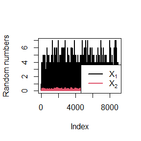

```r
plot(x[,1],type='l',col=1,lwd=2,xlab='Index',ylab='Random numbers')
lines(x[,2],col=2,lwd=2)
legend('bottomright',c(expression(X[1]),expression(X[2])), col=1:2,lwd=2)
```

结果分析：

## Question 4

For each of the above exercise, use the Gelman-Rubin method to monitor convergence of the chain, and run the chain until it converges approximately to the target distribution according to $\hat R < 1.2$.

## Answer

使用coda包完成计算$\hat R$, 并将$\hat R$的统计序列画出来。

首先是柯西分布的马尔科夫链

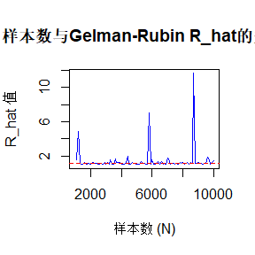

```r
rm(list=ls()) #清理内存
library(coda)
set.seed(24002027)

    normal.chain <- function(sigma, N, X1) {
      x <- rep(0, N)
      x[1]=X1
      u <- runif(N)

     for (i in 2:N) {
     xt <- x[i-1]
     y <- rnorm(1, mean = xt, sd = sigma)
     num <- (dcauchy(y,0,1) * dnorm(xt, y, sigma))
     den <- (dcauchy(xt,0,1) * dnorm(y, xt, sigma))

     if (u[i] <= num / den) {
       x[i] <- y
     }
     else {
       x[i] <- x[i-1]
     }
     }
  return(x)
}

  # 设置参数
burn_in <- 1000
sigma <- 1
initial_values <- c(0, 5, -5)  # 初始值，用于生成多条链

# 定义样本数范围
sample_sizes <- seq(1000, 10000, by = 100)  # 每次增加500个样本
r_hat_values <- numeric(length(sample_sizes))  # 存储每个N下的R_hat值

# 计算每个样本数下的R_hat值
for (i in seq_along(sample_sizes)) {
  N <- sample_sizes[i]

  # 生成多条链
  chains <- lapply(initial_values, function(init) normal.chain(sigma, N, init))

  # 将每条链转换为mcmc对象并丢弃Burn-in部分
  chains <- lapply(chains, function(chain) mcmc(chain[-(1:burn_in)]))

  # 创建mcmc.list对象
  mcmc_chains <- mcmc.list(chains)

  # 计算Gelman-Rubin诊断的点估计值 (Point est.)
  r_hat_values[i] <- gelman.diag(mcmc_chains)$psrf[, "Point est."][1]
}

# 绘制N与R_hat的关系图
plot(sample_sizes, r_hat_values, type="l", pch = 19, col = "blue",
     xlab = "样本数 (N)", ylab = "R_hat 值",
     main = "样本数与Gelman-Rubin R_hat的关系")
abline(h = 1.2, col = "red", lty = 2)  # 添加1.2的参考线
```

结果分析：

柯西分布的样本往往会出现极端值或离群值，这些值会使链在不同初始位置的波动较大，从而导致不同链之间的差异很难缩小，导致数据难以收敛。

对于练习9.8

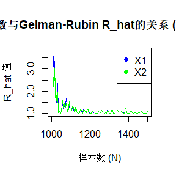

```r
rm(list=ls()) #清理内存
library(coda)
set.seed(24002027)

# 设置Gibbs采样参数
n <- 10
a <- 1
b <- 1
burn <- 1000
initial_values <- list(c(0, 0.5), c(5, 0.8), c(9, 0.2))  # 初始值，用于生成多条链

# 定义样本数范围
sample_sizes <- seq(1000, 1500, by = 5)  # 每次增加500个样本
r_hat_x1_values <- numeric(length(sample_sizes))  # 存储每个样本数下X1的R_hat值
r_hat_x2_values <- numeric(length(sample_sizes))  # 存储每个样本数下X2的R_hat值

# 定义Gibbs采样函数
gibbs_sampler <- function(n, a, b, N, init) {
  X <- matrix(0, N, 2)  # 存储样本链的矩阵
  X[1, ] <- init         # 设置初始值
  for (i in 2:N) {
    x2 <- X[i-1, 2]
    # 从条件分布 P(x|y) 中抽样得到新的 x 值
    X[i, 1] <- rbinom(1, n, x2)
    x1 <- X[i, 1]
    # 从条件分布 P(y|x) 中抽样得到新的 y 值
    X[i, 2] <- rbeta(1, x1 + a, n - x1 + b)
  }
  return(X)
}

# 计算每个样本数下的R_hat值
for (i in seq_along(sample_sizes)) {
  N <- sample_sizes[i]

  # 生成多条链
  chains <- lapply(initial_values, function(init) gibbs_sampler(n, a, b, N, init))

  # 将每条链的后半段（去除burn-in）分别转化为mcmc对象
  chains_x1 <- lapply(chains, function(chain) mcmc(chain[-(1:burn), 1]))
  chains_x2 <- lapply(chains, function(chain) mcmc(chain[-(1:burn), 2]))

  # 创建mcmc.list对象
  mcmc_chains_x1 <- mcmc.list(chains_x1)
  mcmc_chains_x2 <- mcmc.list(chains_x2)

  # 计算Gelman-Rubin诊断的点估计值 (Point est.)
  r_hat_x1_values[i] <- gelman.diag(mcmc_chains_x1)$psrf[, "Point est."][1]
  r_hat_x2_values[i] <- gelman.diag(mcmc_chains_x2)$psrf[, "Point est."][1]
}

# 绘制N与R_hat的关系图
plot(sample_sizes, r_hat_x1_values, type="l", pch = 19, col = "blue",
     xlab = "样本数 (N)", ylab = "R_hat 值",
     main = "样本数与Gelman-Rubin R_hat的关系 (X1 和 X2)")
lines(sample_sizes, r_hat_x2_values, type="l", pch = 19, col = "green")
legend("topright", legend = c("X1", "X2"), col = c("blue", "green"), pch = 19)
abline(h = 1.2, col = "red", lty = 2)  # 添加1.2的参考线
```

结果分析；

可以看出使用Gibbs采样得到的数据很快收敛。

附： 不引入包的情况下模仿书上的代码监视练习9.3柯西分布随机数的收敛。

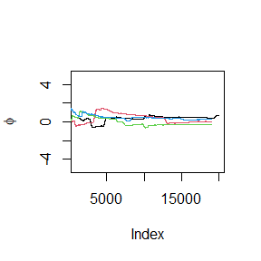

```r
rm(list=ls()) #清理内存
set.seed(24002027)

Gelman.Rubin <- function(psi) {
        # psi[i,j] is the statistic psi(X[i,1:j])
        # for chain in i-th row of X
        psi <- as.matrix(psi)
        n <- ncol(psi)
        k <- nrow(psi)

        psi.means <- rowMeans(psi)     #row means
        B <- n * var(psi.means)        #between variance est.
        psi.w <- apply(psi, 1, "var")  #within variances
        W <- mean(psi.w)               #within est.
        v.hat <- W*(n-1)/n + (B/n)     #upper variance est.
        r.hat <- v.hat / W             #G-R statistic
        return(r.hat)
        }



    normal.chain <- function(sigma, N, X1) {
      x <- rep(0, N)
      x[1]=X1
      u <- runif(N)

     for (i in 2:N) {
     xt <- x[i-1]
     y <- rnorm(1, mean = xt, sd = sigma)
     num <- (dcauchy(y,0,1) * dnorm(xt, y, sigma))
     den <- (dcauchy(xt,0,1) * dnorm(y, xt, sigma))

     if (u[i] <= num / den) {
       x[i] <- y
     }
     else {
       x[i] <- x[i-1]
     }
     }
  return(x)
}



    sigma <- 1     #parameter of proposal distribution
    k <- 4          #number of chains to generate
    n <- 20000      #length of chains
    b <- 1000       #burn-in length

    # 初始值
    x0 <- c(-10, -5 ,5 , 10)

    #生成链
    set.seed(12345)
    X <- matrix(0, nrow=k, ncol=n)
    for (i in 1:k){
        X[i, ] <- normal.chain(sigma, n, x0[i])
}
    #compute diagnostic statistics
    psi <- t(apply(X, 1, cumsum))
    for (i in 1:nrow(psi)){
        psi[i,] <- psi[i,] / (1:ncol(psi))
}
    #plot psi for the four chains
#    par(mfrow=c(2,2))
    for (i in 1:k)
      if(i==1){
        plot((b+1):n,psi[i, (b+1):n],ylim=c(-5, 5), type="l",
            xlab='Index', ylab=bquote(phi))
      }else{
        lines(psi[i, (b+1):n], col=i)
    }
```

```r
    par(mfrow=c(1,1)) #restore default
```

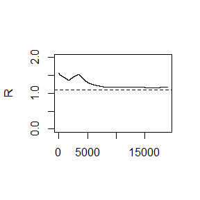

```r
    # 计算R_hat的统计序列
    rhat <- rep(0, n)
    for (j in (b+1):n)
        rhat[j] <- Gelman.Rubin(psi[,1:j])
    plot(rhat[(b+1):n], ylim=c(0, 2), type="l", xlab="", ylab="R")
    abline(h=1.1, lty=2)
```

# A-SC24002027-2024-11-04

## Question 1

1. Write a function to compute the $k^{\text{th}}$ term in

$$\sum_{k=0}^{\infty}\frac{(-1)^{k}}{k! 2^{k}}\frac{\|a\|^{2 k+2}}{(2
k+1)(2
k+2)}\frac{\Gamma\left(\frac{d+1}{2}\right)\Gamma\left(k+\frac{3}{2}\right)}{\Gamma\left(k+\frac{d}{2}+1\right)},$$

where $d \geq 1$ is an integer, a is a vector in $R^{d}$, and $\|\cdot\|$ denotes the Euclidean norm. Perform the arithmetic so that the coefficients can be computed for (almost) arbitrarily large k and d. (This sum converges for all $a \in R^d$).

2. Modify the function so that it computes and returns the sum.
3. Evaluate the sum when $a = (1, 2)^T$.

## Answer

```r
rm(list = ls())
# 计算第k项
compute_kth_term <- function(k, d, a) {
  norm_a <- sqrt(sum(a^2)) # 计算a的欧几里得范数
  term <- ((-1)^k / (factorial(k) * 2^k)) * ((norm_a^(2*k + 2)) / ((2*k + 1) * (2*k + 2))) *
    gamma((d + 1) / 2) * gamma(k + 3/2) / gamma(k + d/2 + 1)
  return(term)
}

# 计算前k项和
compute_series_sum <- function(max_k, d, a) {
  sum_value <- 0
  for (k in 0:max_k) {
    sum_value <- sum_value + compute_kth_term(k, d, a)
  }
  return(sum_value)
}

# 给定a计算总和
a=c(1,2)
max_k <- 100
sum_result <- compute_series_sum(max_k, length(a), a)
print(sum_result)
```

```
## [1] 1.532164
```

结果：1.532164

## Question 2

Write a function to solve the equation

$$\begin{align*}
\frac{2\Gamma\left(\frac{k}{2}\right)}{\sqrt{\pi(k-1)}\Gamma\left(\frac{k-1}{2}\right)}
&\int_{0}^{c_{k-1}}\left(1+\frac{u^{2}}{k-1}\right)^{-k/2} du \\
&= \frac{2\Gamma\left(\frac{k+1}{2}\right)}{\sqrt{\pi
k}\Gamma\left(\frac{k}{2}\right)}\int_{0}^{c_{k}}\left(1+\frac{u^{2}}{k}\right)^{-(k+1)/2}
du
\end{align*}$$

for a, where

$$c_k = \sqrt{\frac{a^2 k}{k+1-a^2}}.$$
Compare the solutions with the points $A(k)$ in Exercise 11.4.

## Answer

步骤： 1. 写出c_k、积分部分的函数。 2. 由于方程两边形式相同，仅取决于k还是k+1，列出左边或右边的函数。 3. 左边减右边，并使用uniroot找零点，零点就是方程的根。

```r
rm(list = ls())
solve_equation = function (k) {

  # 函数中的积分部分
  integration = function(u, n) {
    (1 + u^2/(n-1))^(-n/2)
  }

  # c_k
  c_k = function (n, a) {
    sqrt(a^2 * n / (n + 1 - a^2))
  }

  # 等号两边的函数有相同的形式，区别在于k或者k+1
  left_right = function (n, a) {

    this_integral = function (u) {
      integration(u, n)
    }

    c = c_k(n - 1, a)

    2/sqrt(pi*(n-1)) * exp(lgamma(n/2)-lgamma((n-1)/2)) * integrate(this_integral, lower = 0, upper = c)$value
  }

# 计算等号两边函数的差
  f = function (a) {
    left = left_right(k, a)
    right = left_right(k + 1, a)
    return (left - right)
  }

# 找零点，计算根
  eps = 1e-2
  if (f(eps) < 0 && f(sqrt(k) - eps) > 0 || f(eps) > 0 && f(sqrt(k) - eps) < 0) {
    r = uniroot(f, interval = c(eps, sqrt(k)-eps))$root
  } else {
    r = NA
  }
  return(r)
}

# 把11.4中的值带入
result = sapply(c(4:25, 100, 500, 1000), function (k) {
  solve_equation(k)
})
print(result)
```

```
##  [1] 1.492073 1.533555 1.562745 1.584429 1.601184 1.614516 1.625389 1.634418
##  [9] 1.642026 1.648552 1.654175 1.659099 1.663454 1.667287       NA 1.673832
## [17] 1.676605 1.679148 1.681468 1.683593 1.685546 1.687366       NA       NA
## [25] 1.730903
```

## Question 3

0.54, 0.48, 0.33, 0.43, 1.00, 1.00, 0.91, 1.00, 0.21, 0.85

## Answer

步骤： 1. 设定$\lambda$初始值，和其他数据。 2. 数用期望来处理被截去数据 3. 更新参数 4. 循环3，4直到收敛 5. 计算结果

```r
rm(list = ls())
# 观测到的数据
Y <- c(0.54, 0.48, 0.33, 0.43, 1.00, 1.00, 0.91, 1.00, 0.21, 0.85)

# 截断值
tau <- 1

# 初始化lambda的值，使用没有被截断的数据的均值
lambda <- mean(Y[Y < tau])

# 设置EM算法的参数
tolerance <- 1e-6
max_iter <- 1000
iter <- 0
diff <- tolerance + 1

# EM算法
while (diff > tolerance && iter < max_iter) {
  iter <- iter + 1
  lambda_old <- lambda

  # E步骤：计算被截断的概率
  uncensored <- Y[Y < tau] # 没有被截断的数据
  censored <- Y[Y == tau]  # 被截断的数据

  # 对于指数分布的数据计算被截断数据的期望
  E_censored <- tau + 1 / lambda_old

  # M步骤：更新lambda
  lambda <- length(Y) / (sum(uncensored) + length(censored) * E_censored)

  # 检查收敛性
  diff <- abs(lambda - lambda_old)
}

# 输出结果
cat("通过EM算法估计的lambda:", lambda, "\n")
```

```
## 通过EM算法估计的lambda: 1.037037
```

```r
# 使用观测数据的MLE估计
lambda_mle <- 1 / mean(Y)
cat("观测数据的MLE估计的lambda:", lambda_mle, "\n")
```

```
## 观测数据的MLE估计的lambda: 1.481481
```

对比两个结果可以看出，法EM算法能够更准确地估计$\lambda$，因为它利用了截断数据的隐含信息，修正了MLE估计的偏差。

# A-SC24002027-2024-11-11

## Question 1

11.7

Use the simplex algorithm to solve the following problem. Minimize $4x + 2y + 9z$ subject to
$$2x + y + z \leq 2 \\
x - y + 3z \leq 3 \\
x \geq 0, \quad y \geq 0, \quad z \geq 0.$$

## Answer

思路：使用lp包解决线性规划问题。

1. 定义目标函数的系数 (最小化目标)，定义约束矩阵，定义约束的右侧值，定义约束方向
2. 用lp求解线性规划

```r
rm(list = ls()) # 清理缓存

# 加载 lpSolve 包
library(lpSolve)

# 定义目标函数的系数 (最小化目标)
obj_coef <- c(4, 2, 9)

# 定义约束矩阵
constraints <- matrix(c(
  2,  1,  1,  # 2x + y + z <= 2
  1, -1,  3   # x - y + 3z <= 3
), nrow = 2, byrow = TRUE)

# 定义约束的右侧值
rhs <- c(2, 3)

# 定义约束方向
directions <- c("<=", "<=")

# 求解线性规划
solution <- lp("min", obj_coef, constraints, directions, rhs, compute.sens = TRUE)

# 输出结果
if (solution$status == 0) {
  cat("目标函数最小值：", solution$objval, "\n")
  cat("决策变量的取值：\n")
  print(solution$solution)
} else {
  cat("未找到最优解。\n")
}
```

```
## 目标函数最小值： 0
## 决策变量的取值：
## [1] 0 0 0
```

结果：根据结果可知，目标函数最小值为0，此时x、y、z的取值均为零。

## Question 2

3. Use both for loops and lapply() to fit linear models to the mtcars using the formulas stored in this list:

formulas <- list( mpg ~ disp, mpg ~ I(1 / disp), mpg ~ disp + wt, mpg ~ I(1 / disp) + wt )

4. Fit the model mpg ~ disp to each of the bootstrap replicates of mtcars in the list below by using a for loop and lapply(). Can you do it without an anonymous function?

bootstraps <- lapply(1:10, function(i) { rows <- sample(1:nrow(mtcars), rep = TRUE) mtcars[rows, ] })

5. For each model in the previous two exercises, extract $R^2$ using the function below.

rsq <- function(mod) summary(mod)$r.squared

## Answer

3. 使用 for 循环和 lapply 分别对公式中的公式线性拟合。

```r
rm(list = ls()) # 清理缓存
# 准备数据和公式
data(mtcars)
formulas <- list(
  mpg ~ disp,
  mpg ~ I(1 / disp),
  mpg ~ disp + wt,
  mpg ~ I(1 / disp) + wt
)

# 使用 for 循环
models_for <- list()
for (i in seq_along(formulas)) {
  models_for[[i]] <- lm(formulas[[i]], data = mtcars)
}

# 使用 lapply()
models_lapply <- lapply(formulas, function(formula) lm(formula, data = mtcars))

# 查看结果
models_for
```

```
## [[1]]
##
## Call:
## lm(formula = formulas[[i]], data = mtcars)
##
## Coefficients:
## (Intercept)         disp
##    29.59985     -0.04122
##
##
## [[2]]
##
## Call:
## lm(formula = formulas[[i]], data = mtcars)
##
## Coefficients:
## (Intercept)    I(1/disp)
##       10.75      1557.67
##
##
## [[3]]
##
## Call:
## lm(formula = formulas[[i]], data = mtcars)
##
## Coefficients:
## (Intercept)         disp           wt
##    34.96055     -0.01772     -3.35083
##
##
## [[4]]
##
## Call:
## lm(formula = formulas[[i]], data = mtcars)
##
## Coefficients:
## (Intercept)    I(1/disp)           wt
##      19.024     1142.560       -1.798
```

```r
models_lapply
```

```
## [[1]]
##
## Call:
## lm(formula = formula, data = mtcars)
##
## Coefficients:
## (Intercept)         disp
##    29.59985     -0.04122
##
##
## [[2]]
##
## Call:
## lm(formula = formula, data = mtcars)
##
## Coefficients:
## (Intercept)    I(1/disp)
##       10.75      1557.67
##
##
## [[3]]
##
## Call:
## lm(formula = formula, data = mtcars)
##
## Coefficients:
## (Intercept)         disp           wt
##    34.96055     -0.01772     -3.35083
##
##
## [[4]]
##
## Call:
## lm(formula = formula, data = mtcars)
##
## Coefficients:
## (Intercept)    I(1/disp)           wt
##      19.024     1142.560       -1.798
```

二者得到的结果相同。

4. 使用 for 循环和 lapply() 对 bootstraps 中的每个样本拟合线性模型

```r
# 创建 bootstrap 样本
bootstraps <- lapply(1:10, function(i) {
  rows <- sample(1:nrow(mtcars), replace = TRUE)
  mtcars[rows, ]
})

# 使用 for 循环
bootstrap_models_for <- list()
for (i in seq_along(bootstraps)) {
  bootstrap_models_for[[i]] <- lm(mpg ~ disp, data = bootstraps[[i]])
}

# 使用 lapply()
bootstrap_models_lapply <- lapply(bootstraps, lm, formula = mpg ~ disp)

# 查看结果
bootstrap_models_for
```

```
## [[1]]
##
## Call:
## lm(formula = mpg ~ disp, data = bootstraps[[i]])
##
## Coefficients:
## (Intercept)         disp
##    30.71583     -0.04754
##
##
## [[2]]
##
## Call:
## lm(formula = mpg ~ disp, data = bootstraps[[i]])
##
## Coefficients:
## (Intercept)         disp
##    29.12901     -0.03887
##
##
## [[3]]
##
## Call:
## lm(formula = mpg ~ disp, data = bootstraps[[i]])
##
## Coefficients:
## (Intercept)         disp
##    28.92955     -0.03931
##
##
## [[4]]
##
## Call:
## lm(formula = mpg ~ disp, data = bootstraps[[i]])
##
## Coefficients:
## (Intercept)         disp
##    29.00030     -0.04009
##
##
```

[output cut: 43 more lines]

```
## lm(formula = mpg ~ disp, data = bootstraps[[i]])
##
## Coefficients:
## (Intercept)         disp
##     28.7887      -0.0385
##
##
## [[10]]
##
## Call:
## lm(formula = mpg ~ disp, data = bootstraps[[i]])
##
## Coefficients:
## (Intercept)         disp
##    28.74223     -0.03774
```

```r
bootstrap_models_lapply
```

```
## [[1]]
##
## Call:
## FUN(formula = ..1, data = X[[i]])
##
## Coefficients:
## (Intercept)         disp
##    30.71583     -0.04754
##
##
## [[2]]
##
## Call:
## FUN(formula = ..1, data = X[[i]])
##
## Coefficients:
## (Intercept)         disp
##    29.12901     -0.03887
##
##
## [[3]]
##
## Call:
## FUN(formula = ..1, data = X[[i]])
##
## Coefficients:
## (Intercept)         disp
##    28.92955     -0.03931
##
##
## [[4]]
##
## Call:
## FUN(formula = ..1, data = X[[i]])
##
## Coefficients:
## (Intercept)         disp
##    29.00030     -0.04009
##
##
```

[output cut: 43 more lines]

```
## FUN(formula = ..1, data = X[[i]])
##
## Coefficients:
## (Intercept)         disp
##     28.7887      -0.0385
##
##
## [[10]]
##
## Call:
## FUN(formula = ..1, data = X[[i]])
##
## Coefficients:
## (Intercept)         disp
##    28.74223     -0.03774
```

二者得到的结果相同。

5. 提取 $R^2$

```r
# 定义 R^2 提取函数
rsq <- function(mod) summary(mod)$r.squared

# 提取 for 循环中模型的 R^2
rsq_for <- sapply(models_for, rsq)
rsq_for_bootstrap <- sapply(bootstrap_models_for, rsq)

# 提取 lapply() 中模型的 R^2
rsq_lapply <- sapply(models_lapply, rsq)
rsq_lapply_bootstrap <- sapply(bootstrap_models_lapply, rsq)

# 查看结果
rsq_for
```

```
## [1] 0.7183433 0.8596865 0.7809306 0.8838038
```

```r
rsq_for_bootstrap
```

```
##  [1] 0.7752766 0.7015322 0.7007053 0.7369189 0.7505659 0.8380117 0.7274341
##  [8] 0.6195316 0.6468874 0.6376037
```

```r
rsq_lapply
```

```
## [1] 0.7183433 0.8596865 0.7809306 0.8838038
```

```r
rsq_lapply_bootstrap
```

```
##  [1] 0.7752766 0.7015322 0.7007053 0.7369189 0.7505659 0.8380117 0.7274341
##  [8] 0.6195316 0.6468874 0.6376037
```

结果分析：

for循环与lapply()得到了相同的结果，但总体来说，使用lapply()能减少内存的使用，并使代码更简洁清晰。

## Question 3

3. The following code simulates the performance of a t-test for non-normal data. Use sapply() and an anonymous function to extract the p-value from every trial.

trials <- replicate( 100, t.test(rpois(10, 10), rpois(7, 10)), simplify = FALSE )

6. Implement a combination of Map() and vapply() to create an lapply() variant that iterates in parallel over all of its inputs and stores its outputs in a vector (or a matrix). What arguments should the function take?

## Answer

3. 使用中 sapply() 和匿名函数提取每次试验的 p 值，并对提取的p值可视化。

```r
rm(list = ls()) # 清理缓存
# 模拟数据
trials <- replicate(
  100,
  t.test(rpois(10, 10), rpois(7, 10)),
  simplify = FALSE
)

# 使用 sapply() 和匿名函数提取 p 值
p_values <- sapply(trials, function(test) test$p.value)

# 查看结果
p_values
```

```
##   [1] 0.467948775 0.616526328 0.518824931 0.216111945 0.516725823 0.110632293
##   [7] 0.151041451 0.975556000 0.652972890 0.560291972 0.389067690 0.139455063
##  [13] 0.154889462 0.666677905 0.314295640 0.386475142 0.732188028 0.899059830
##  [19] 0.400342442 0.211813576 0.126554302 0.734072607 0.372516395 0.758383737
##  [25] 0.894606354 0.786102245 0.395417828 0.705332428 0.476841647 0.424505951
##  [31] 0.462699357 0.041379404 0.935706478 0.281034275 0.741782786 0.215408287
##  [37] 0.912870499 0.418138397 0.622740955 0.361132201 0.610680817 0.084276976
##  [43] 0.060233931 0.276964680 0.154853290 0.719288150 0.428581525 0.140505714
##  [49] 0.610766041 0.470915665 0.726661182 0.914502669 0.040754344 0.351725517
##  [55] 0.454925832 0.388902300 0.963932425 0.568374352 0.678338620 0.504387389
##  [61] 0.954459928 0.447554174 0.187153969 0.977221079 0.896124616 0.581159392
##  [67] 0.395337135 0.401755679 0.525189922 0.260343628 0.653171281 0.838498497
##  [73] 0.745202289 0.309526928 0.233912286 0.213751345 0.109408771 0.892547265
##  [79] 0.231590558 0.452297314 0.773179927 0.942408177 0.321515623 0.571209869
##  [85] 0.923409231 0.220408345 0.006523058 0.036237785 0.405659799 0.728172959
##  [91] 0.598782800 0.572148297 0.560927617 0.717504596 0.818230597 0.205145629
##  [97] 0.015699982 0.229720880 0.154728560 0.530439876
```

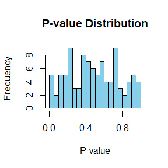

```r
hist(p_values, breaks = 20, main = "P-value Distribution", xlab = "P-value", col = "skyblue")
```

6. Map() 和 vapply() 可以结合使用，创建一个类似于 lapply() 的函数，并使用。

思路：

Map()：将多个输入列表逐元素并行传递给目标函数 FUN，并返回一个列表。

vapply()：对 Map() 的输出列表进行转换，并强制结果符合指定的 FUN.VALUE 类型。

identity：用于在 vapply() 中直接返回列表中的元素。

```r
# 自定义函数：结合 Map() 和 vapply()
parallel_lapply <- function(FUN, ..., FUN.VALUE) {
  # 使用 Map() 并行迭代所有输入
  results <- Map(FUN, ...)
  # 使用 vapply() 将结果强制转换为指定类型（向量或矩阵）
  vapply(results, identity, FUN.VALUE)
}

# 示例 1：并行迭代两个列表并计算它们的和
list1 <- list(1, 2, 3)
list2 <- list(4, 5, 6)

result <- parallel_lapply(
  FUN = function(x, y) x + y,  # 目标函数
  list1, list2,               # 多个输入
  FUN.VALUE = numeric(1)      # 输出为数值向量
)
print(result)
```

```
## [1] 5 7 9
```

```r
# 示例 2：生成矩阵输出
list3 <- list(7, 8, 9)

result_matrix <- parallel_lapply(
  FUN = function(x, y, z) c(x, y, z),  # 目标函数，返回向量
  list1, list2, list3,                # 多个输入
  FUN.VALUE = numeric(3)              # 输出为矩阵
)
print(result_matrix)
```

```
##      [,1] [,2] [,3]
## [1,]    1    2    3
## [2,]    4    5    6
## [3,]    7    8    9
```

参数： FUN：目标函数，定义对输入如何处理。

…：多个输入列表，这些列表将在 Map() 中并行迭代。

FUN.VALUE：定义目标函数输出的模板，用于 vapply() 检查和强制结果的格式。它决定了输出是向量还是矩阵：

numeric(1)：结果为数值向量。

numeric(n)：结果为矩阵，n 是每个结果的长度。

## Question 4

4. Make a faster version of chisq.test() that only computes the chi-square test statistic when the input is two numeric vectors with no missing values. You can try simplifying chisq.test() or by coding from the mathematical definition (http://en. wikipedia.org/wiki/Pearson%27s_chi-squared_test).
5. Can you make a faster version of table() for the case of an input of two integer vectors with no missing values? Can you use it to speed up your chi-square test?

## Answer

对于两个数值向量x和y, 我们可以直接根据其频数分布计算卡方检验统计量的观察值和期望值。

函数思路：

1. 输入检查：

确保输入是两个数值向量。

确保输入中没有缺失值。

2. 计算步骤：

使用 table() 计算二维列联表作为观察值。

根据行和列的总和计算期望值。

根据公式计算卡方统计量。

3. 输出：

返回卡方检验统计量。

```r
rm(list = ls()) # 清理缓存
# 更快的卡方检验函数
fast_chisq <- function(x, y) {
  # 确保输入为数值向量，且无缺失值
  stopifnot(is.numeric(x), is.numeric(y), !anyNA(x), !anyNA(y))

  # 构建二维列联表
  observed <- table(x, y)

  # 计算期望值
  row_totals <- rowSums(observed)
  col_totals <- colSums(observed)
  grand_total <- sum(observed)
  expected <- outer(row_totals, col_totals) / grand_total

  # 计算卡方检验统计量
  chisq_stat <- sum((observed - expected)^2 / expected)

  return(chisq_stat)
}

# 示例数据
x <- c(1, 1, 2, 2, 2, 3, 3, 3, 3, 4, 4, 4)
y <- c(1, 2, 2, 3, 3, 1, 2, 2, 3, 1, 3, 3)

# 调用函数
fast_chisq(x, y)
```

```
## [1] 4.833333
```

结果与使用chisq.test() 得到的相同。

5. 我们可以通过实现一个针对两个整数向量优化的 table() 函数来加速生成列联表。

思路：

1. 针对整数向量，可以避免了标准 table() 中的类型转换和其他检查步骤。
2. 利用 match() 定位值在唯一值中的位置，填充矩阵。

```r
# 自定义快速 table() 函数
fast_table <- function(x, y) {
  # 确保输入为整数向量，且无缺失值
  stopifnot(is.integer(x), is.integer(y), !anyNA(x), !anyNA(y))

  # 确定唯一值及其范围
  x_levels <- sort(unique(x))
  y_levels <- sort(unique(y))

  # 创建结果矩阵
  result <- matrix(0L, nrow = length(x_levels), ncol = length(y_levels))
  rownames(result) <- x_levels
  colnames(result) <- y_levels

  # 填充计数
  for (i in seq_along(x)) {
    result[match(x[i], x_levels), match(y[i], y_levels)] <-
      result[match(x[i], x_levels), match(y[i], y_levels)] + 1
  }

  return(result)
}

# 引入到卡方检验
fast_chisq_optimized <- function(x, y) {
  # 确保输入为整数向量
  stopifnot(is.integer(x), is.integer(y), !anyNA(x), !anyNA(y))

  # 使用快速 table 生成列联表
  observed <- fast_table(x, y)

  # 计算期望值
  row_totals <- rowSums(observed)
  col_totals <- colSums(observed)
  grand_total <- sum(observed)
  expected <- outer(row_totals, col_totals) / grand_total

  # 计算卡方检验统计量
  chisq_stat <- sum((observed - expected)^2 / expected)

  return(chisq_stat)
}

# 示例数据（整数向量）
x <- as.integer(c(1, 1, 2, 2, 2, 3, 3, 3, 3, 4, 4, 4))
y <- as.integer(c(1, 2, 2, 3, 3, 1, 2, 2, 3, 1, 3, 3))

# 调用优化后的卡方检验函数
fast_chisq_optimized(x, y)
```

```
## [1] 4.833333
```

结果分析：得到的结果与前面相同。

# A-SC24002027-2024-11-18

## Question 1

9.8

This example appears in [40]. Consider the bivariate density
$$f(x, y) \propto \binom{n}{x} y^{x+a-1}(1-y)^{n-x+b-1}, \quad
x=0,1,\ldots, n, \quad 0 \leq y \leq 1.$$
It can be shown (see e.g. [23]) that for fixed a, b, n, the conditional distributions are Binomial(n, y) and Beta(x + a, n − x + b). Use the Gibbs sampler to generate a chain with target joint density f (x, y).

1. Write an Rcpp function for Exercise 9.8 (page 278, Statistical Computing with R)
2. Compare the corresponding generated random numbers with those by the R function you wrote using the function “qqplot”.
3. Campare the computation time of the two functions with the function “microbenchmark”.
4. Comments your results.

## Answer

思路:

Gibbs 采样器

1. 设置起始值
2. 重复 for i=2,…,N
   1. 从x条件概率分布中生成$x^* (t) = f_x(\cdot \mid x_{2})$, 从y条件概率分布中生成$y^* (t) = f(\cdot \mid x^* (t))$
   2. x=(x^* (t), y^* (t))
   3. 除去烧入

分别用cpp和r语言编写函数，再用qq图对比结果，再比较消耗时间。

1.分别用cpp和r语言编写函数

```r
rm(list = ls()) # 清理内存

# r语言Gibbs 采样器
gibbs_r <- function(n_iter, n, a, b, burn) {
  chain <- matrix(0, nrow = n_iter, ncol = 2) # 存储最终保留的样本
  x <- 0  # 初始化 x
  y <- 0.5  # 初始化 y

  for (i in 1:(n_iter + burn)) {
    # 从条件分布 x | y (二项分布) 采样
    x <- rbinom(1, n, y)

    # 从条件分布 y | x (Beta 分布) 采样
    y <- rbeta(1, x + a, n - x + b)

    # 如果超出 burn-in 阶段，则存储样本
    if (i > burn) {
      chain[i - burn, ] <- c(x, y)
    }
  }
  return(chain) # 返回最终样本链
}
```

```r
library(Rcpp)
cppFunction('NumericMatrix gibbs_cpp(int n_iter, int n, double a, double b, int burn) {
  NumericMatrix chain(n_iter, 2); // 存储最终保留的 (x, y) 样本
  double x = 0;                  // 初始化 x
  double y = 0.5;                // 初始化 y

  for (int i = 0; i < n_iter + burn; i++) {
    // 从条件分布 x | y (二项分布) 采样
    x = R::rbinom(n, y);

    // 从条件分布 y | x (Beta 分布) 采样
    y = R::rbeta(x + a, n - x + b);

    // 如果超出 burn-in 阶段，则存储样本
    if (i >= burn) {
      chain(i - burn, 0) = x; // 存储 x
      chain(i - burn, 1) = y; // 存储 y
    }
  }
  return chain; // 返回最终样本链
}
')
```

2.计算并比较结果

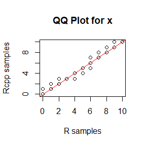

```r
set.seed(24002027)


# 设置参数
n_iter <- 10000
burn <- 1000
n <- 10
a <- 1
b <- 1

# 生成数据
chain_r <- gibbs_r(n_iter, n, a, b, burn)
chain_cpp <- gibbs_cpp(n_iter, n, a, b, burn)

# 对比x
qqplot(chain_r[, 1], chain_cpp[, 1], main = "QQ Plot for x",
       xlab = "R samples", ylab = "Rcpp samples")
abline(0, 1, col = "red")
```

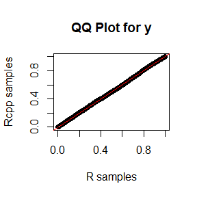

```r
# 对比y
qqplot(chain_r[, 2], chain_cpp[, 2], main = "QQ Plot for y",
       xlab = "R samples", ylab = "Rcpp samples")
abline(0, 1, col = "red")
```

3.比较时间

```r
library(microbenchmark)

time <- microbenchmark(
  R = gibbs_r(n_iter, n, a, b, burn),
  Rcpp = gibbs_cpp(n_iter, n, a, b, burn),
  times = 10
)

print(time)
```

```
## Unit: milliseconds
##  expr     min      lq     mean  median      uq     max neval
##     R 27.1166 27.3688 29.11744 27.7064 29.8797 34.4568    10
##  Rcpp  2.4120  2.4182  2.54025  2.4255  2.4391  3.5656    10
```

5. 结果分析

随机数生成：通过 QQ 图，我们可以看出它们的随机数高度一致, 符合预期。

计算性能：microbenchmark 的结果表明 Rcpp 的实现速度通常显著优于 R 的实现，说明C++语言在随机数生成和循环方面的优化较好。